# Question

A quadratic function, $f$, has zeros at $(x_1,0)$ and $(x_2,0)$.

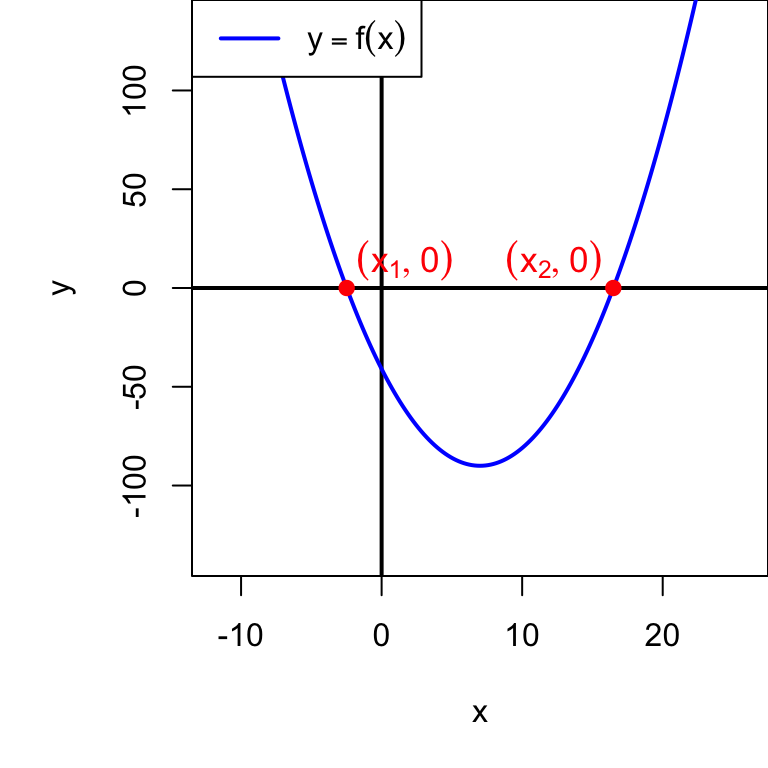

The exact zeros are $7\pm 3\sqrt{10}$.

$$x_1~=~7-3\sqrt{10}$$
$$x_2~=~7+3\sqrt{10}$$

The function $f$ can be expressed in **factored form**, with parameter $a$ adjusting the vertical stretch and orientation of the parabola.

$$f(x)~=~a\cdot
\left[x-(7-3\sqrt{10})\right]\cdot\left[x-(7+3\sqrt{10})\right]$$

The function, expressed in **standard form**, is parameterized with quadratic coefficient $a$, linear coefficient $b$, and constant $c$.

$$f(x)~=~ax^2+bx+c$$

In this case, the quadratic coefficient equals 1.

$$a=1$$

Find the linear coefficient and the constant. You can do this by expanding the factored form and combining like terms.

$b=$ ##ANSWER1##

$c=$ ##ANSWER2##

## Answerlist

- -18
- -14
- -6
- -4
- 4
- 6
- 14
- 18
- -248
- -156
- -111
- -81
- -71
- -41
- -4
- 24

# Solution

Start in factored form. We know $a=1$.

$$f(x)~=~\left[x-(7-3\sqrt{10})\right]\cdot\left[x-(7+3\sqrt{10})\right]$$

At this point, you can either FOIL or distribute away the inside parentheses. I think it’ll be a bit cleaner to distribute the subtraction across the parentheses.

$$\left[x-7+3\sqrt{10}\right]\cdot\left[x-7-3\sqrt{10}\right]$$

But now, instead of FOIL, we need to generalize, because each factor has three terms: a linear term and two constant terms. You could probably guess that we simply multiply each of the first factor’s terms by each of the second factor’s terms.

$$x^2-7x-3\sqrt{10}x-7x+49+21\sqrt{10}+3\sqrt{10}x-21\sqrt{10}-90$$

Combine like terms. Opposite terms cancel each other out.

$$x^2-14x-41$$

Thus, $b=-14$ and $c=-41$.

# Meta-information

extype: cloze exclozetype: schoice|schoice exsolution: 01000000|00000100 exname: abc_from_hpsqrtq_roots